# Comparative analysis

### VIS Reflectivity

```r
pglsmodVIS <- pgls(VIS ~ PC1 + PC2 + size + PC1*size + PC2*size,
  data = comp_data, param.CI = 0.95, lambda = "ML"
)

summary(pglsmodVIS)
```

```
##
## Call:
## pgls(formula = VIS ~ PC1 + PC2 + size + PC1 * size + PC2 * size,
##     data = comp_data, lambda = "ML", param.CI = 0.95)
##
## Residuals:
##     Min      1Q  Median      3Q     Max
## -8.3110 -1.7822 -0.2896  1.3542  5.7361
##
## Branch length transformations:
##
## kappa  [Fix]  : 1.000
## lambda [ ML]  : 1.000
##    lower bound : 0.000, p = 0.01719
##    upper bound : 1.000, p = 1
##    95.0% CI   : (0.640, NA)
## delta  [Fix]  : 1.000
##
## Coefficients:
##             Estimate Std. Error t value Pr(>|t|)
## (Intercept)  -4.7921     9.8591 -0.4861  0.62952
## PC1          -6.1775     3.1509 -1.9606  0.05675 .
## PC2          -6.8310     3.8871 -1.7574  0.08632 .
## size          7.0754     3.0575  2.3141  0.02575 *
## PC1:size      2.7225     1.3429  2.0274  0.04915 *
## PC2:size      2.5631     1.5476  1.6562  0.10532
## ---
## Signif. codes:  0 '***' 0.001 '**' 0.01 '*' 0.05 '.' 0.1 ' ' 1
##
## Residual standard error: 2.824 on 41 degrees of freedom
## Multiple R-squared: 0.2311,  Adjusted R-squared: 0.1373
## F-statistic: 2.465 on 5 and 41 DF,  p-value: 0.04838
```

Results after correcting by phylogeny:

*Size* —-

Remains important. Even after correcting by phylogeny, larger beetles reflect more visible light

*PC1 and PC2* —-

PC1 and PC2 have marginal pvalues. PC1 may have some influence.

*Interactions* —-

PC1-Size-Interaction remains significant: smaller beetles tend to reflect more visible light in more humid environments.

Likelihood surfaces of lambda:

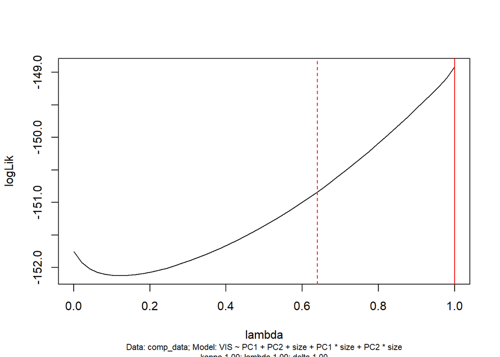

```r
# visualize a likelihood surface
lm.lk.VIS <- pgls.profile(pglsmodVIS, which = "lambda")
plot(lm.lk.VIS)
```

Model diagnostic plots

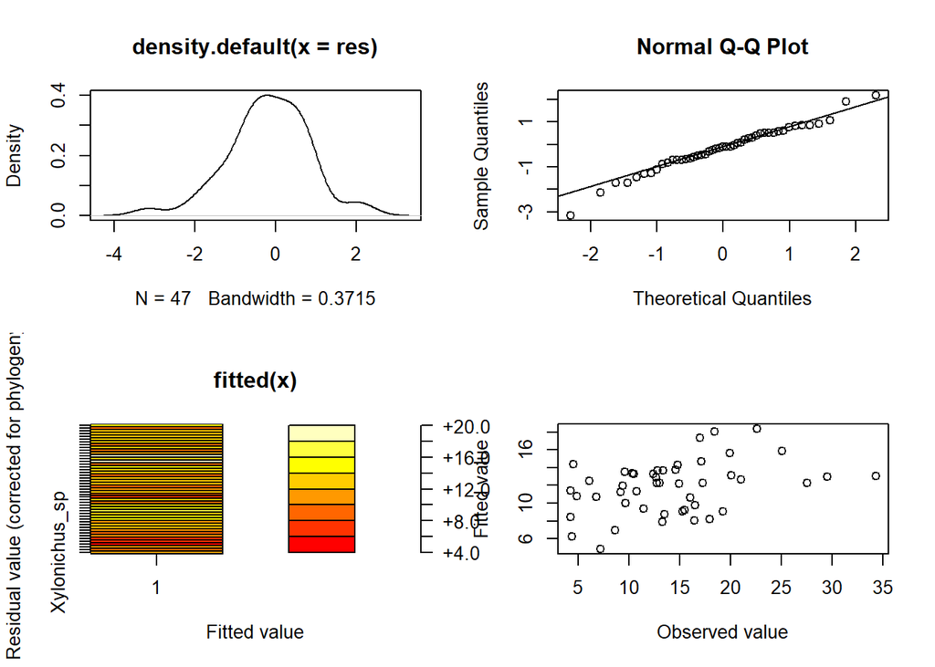

```r
par(mfrow = c(2, 2))
plot(pglsmodVIS)
```

Test phylogenetic signal using Pagel’s lambda

```r
pagelVISRefl <- Cons1agg$VIS # Define which trait you want to test
names(pagelVISRefl) <- rownames(Cons1agg) # Row names = tree tips
phylosig(MCCtree, pagelVISRefl, method = "lambda", test = TRUE, nsim = 999)
```

```
##
## Phylogenetic signal lambda : 0.882589
## logL(lambda) : -154.422
## LR(lambda=0) : 1.87652
## P-value (based on LR test) : 0.17073
```

```r
# nsim = 999 means testing with 999 randomizations
```

### Residuals

```r
pglsmodRes <- pgls(Res ~ PC1 + PC2 + size + PC1*size + PC2*size,
  data = comp_data, param.CI = 0.95, lambda = "ML"
)

summary(pglsmodRes)
```

```
##
## Call:
## pgls(formula = Res ~ PC1 + PC2 + size + PC1 * size + PC2 * size,
##     data = comp_data, lambda = "ML", param.CI = 0.95)
##
## Residuals:
##     Min      1Q  Median      3Q     Max
## -7.2016 -1.2602  0.6708  2.1456  9.4374
##
## Branch length transformations:
##
## kappa  [Fix]  : 1.000
## lambda [ ML]  : 0.992
##    lower bound : 0.000, p = 0.0025491
##    upper bound : 1.000, p = 0.81576
##    95.0% CI   : (0.562, NA)
## delta  [Fix]  : 1.000
##
## Coefficients:
##             Estimate Std. Error t value Pr(>|t|)
## (Intercept) 11.34820   11.06305  1.0258  0.31101
## PC1          1.08066    3.58851  0.3011  0.76483
## PC2         11.94226    4.44713  2.6854  0.01041 *
## size        -2.45531    3.49183 -0.7032  0.48593
## PC1:size    -0.22314    1.53169 -0.1457  0.88488
## PC2:size    -4.59158    1.77355 -2.5889  0.01326 *
## ---
## Signif. codes:  0 '***' 0.001 '**' 0.01 '*' 0.05 '.' 0.1 ' ' 1
##
## Residual standard error: 3.115 on 41 degrees of freedom
## Multiple R-squared: 0.216,   Adjusted R-squared: 0.1204
## F-statistic: 2.259 on 5 and 41 DF,  p-value: 0.06644
```

Results after correcting by phylogeny:

*Size* —-

Not significant (as before)

*PC1 and PC2* —-

PC2 remained significant: Beetles in hotter environments have smaller NIR Residuals (reflect less extra NIR from the expected by the VIS-NIR correlation)

*Interactions* —-

PC2-Size-Interaction remains significant: smaller beetles tend to have smaller NIR Residuals in hotter/arid environments.

** It does not necesarily mean they reflect less NIR, it may mean that the amount of NIR and VIS ligth reflected is more similar. Needs further investigation

Likelihood surfaces of lambda

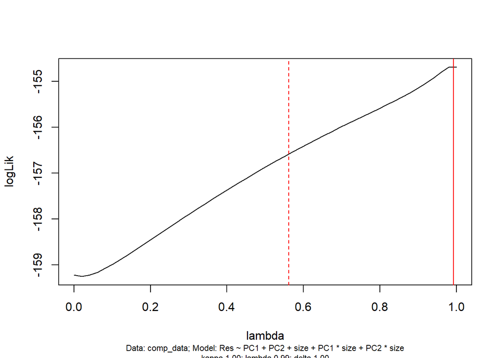

```r
# visualize a likelihood surface
lm.lk.Res <- pgls.profile(pglsmodRes, which = "lambda")
plot(lm.lk.Res)
```

Model diagnostic plots

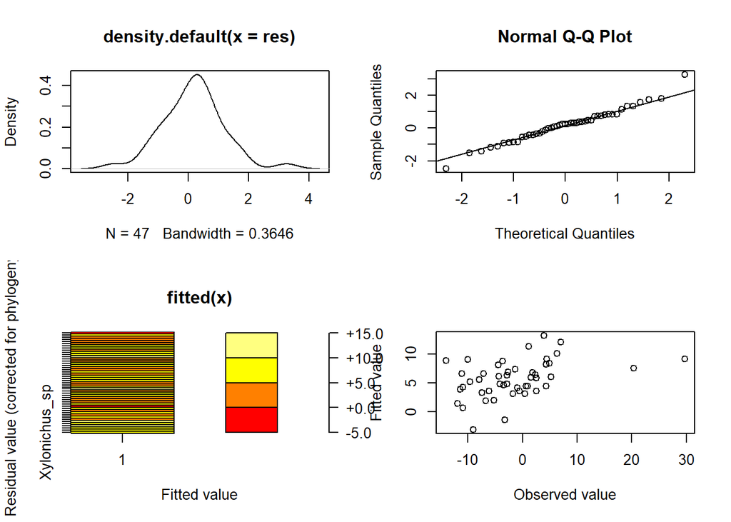

```r
par(mfrow = c(2, 2))
plot(pglsmodRes)
```

Test phylogenetic signal using Pagel’s lambda

```r
pagelRes <- Cons1agg$Res # Define which trait you want to test
names(pagelRes) <- rownames(Cons1agg) # Row names = tree tips
phylosig(MCCtree, pagelRes, method = "lambda", test = TRUE, nsim = 999)
```

```
##
## Phylogenetic signal lambda : 0.933799
## logL(lambda) : -160.155
## LR(lambda=0) : 7.41334
## P-value (based on LR test) : 0.00647419
```

```r
# nsim = 999 means testing with 999 randomizations
```

Phylogenetic signal is very high

## MCMCglmm at species level

It should give us similar results to the PGLS

Model is the same as before

### Set priors for MCMC

```r
# Include 1 Gs = 1 random factors:
# 1) phylogeny (phylogenetic relatedness) = "animal"

prior.sp2 <- list(
  R = list(V = 1, n = 0.002),
  G = list(G1 = list(V = 1, n = 1, alpha.mu = 0, alpha.V = 25^2))
)
```

Prepare data sets

```r
TOTDataSetSpp <-
  Cons1agg %>%
  dplyr::select (-NIR, -VIS, - Res) %>%
  rename ("Reflectance" = TOT)

NIRDataSetSpp <-
  Cons1agg %>%
  dplyr::select (-TOT, -VIS, - Res) %>%
  rename ("Reflectance" = NIR)

VISDataSetSpp <-
  Cons1agg %>%
  dplyr::select (-TOT, -NIR, - Res) %>%
  rename ("Reflectance" = VIS)


ResDataSetSpp <-
  Cons1agg %>%
  dplyr::select (-TOT, -NIR, -VIS) %>%
  rename ("Reflectance" = Res)



TOTDataSetSpp$animal <- factor(TOTDataSetSpp$phylogeny_name)

NIRDataSetSpp$animal <- factor(NIRDataSetSpp$phylogeny_name)

VISDataSetSpp$animal <- factor(VISDataSetSpp$phylogeny_name)

ResDataSetSpp$animal <- factor(ResDataSetSpp$phylogeny_name)
```

Set up the model

```r
mcmcmodel.spp <- Reflectance ~ PC1 + PC2 + size + PC1*size + PC2*size
```

### TOT Reflectivity

```r
mcmcModMCC_TOTsp <- MCMCglmm(mcmcmodel.spp,
  random = ~animal,
  # account for only phylogeny as random factors
  prior = prior.sp2,
  ginverse = list(animal = AinvTA.MCC),
  data = TOTDataSetSpp,
  family = "gaussian",
  nitt = 3000, burnin = 500, thin = 1,
  pl = T,
  pr = F,
  verbose = F,
  singular.ok = T
)

summary(mcmcModMCC_TOTsp)$solutions %>%
  kbl() %>%
  kable_paper("hover", full_width = F)
```

|  | post.mean | l-95% CI | u-95% CI | eff.samp | pMCMC |
| --- | --- | --- | --- | --- | --- |
| (Intercept) | 15.6131401 | -9.533893 | 40.937877 | 2692.717 | 0.2192 |
| PC1 | -5.7084422 | -13.853904 | 2.644600 | 2500.000 | 0.1712 |
| PC2 | -0.6895626 | -11.095544 | 9.143161 | 2303.059 | 0.9176 |
| size | 5.8924661 | -2.654281 | 13.398968 | 2500.000 | 0.1568 |
| PC1:size | 2.6426977 | -0.959236 | 6.075899 | 2500.000 | 0.1440 |
| PC2:size | 0.1991503 | -3.580284 | 4.495532 | 2294.879 | 0.9560 |

None of the variables has a significant effect on TOTAL reflectivity

### NIR Reflectivity

```r
mcmcModMCC_NIRsp <- MCMCglmm(mcmcmodel.spp,
  random = ~animal,
  # account for only phylogeny as random factors
  prior = prior.sp2,
  ginverse = list(animal = AinvTA.MCC),
  data = NIRDataSetSpp,
  family = "gaussian",
  nitt = 3000, burnin = 500, thin = 1,
  pl = T,
  pr = F,
  verbose = F,
  singular.ok = T
)

summary(mcmcModMCC_NIRsp)$solutions %>%
  kbl() %>%
  kable_paper("hover", full_width = F)
```

|  | post.mean | l-95% CI | u-95% CI | eff.samp | pMCMC |
| --- | --- | --- | --- | --- | --- |
| (Intercept) | 35.087510 | 2.189686 | 64.788302 | 2506.65 | 0.0328 |
| PC1 | -5.314777 | -15.272842 | 5.404176 | 2500.00 | 0.3248 |
| PC2 | 4.684485 | -8.007494 | 19.053747 | 2500.00 | 0.4704 |
| size | 4.806283 | -5.286054 | 15.436837 | 2500.00 | 0.3480 |
| PC1:size | 2.597038 | -1.751956 | 7.052082 | 2500.00 | 0.2656 |
| PC2:size | -1.879801 | -7.712762 | 3.108726 | 2500.00 | 0.4744 |

None of the variables has a significant effect on NIR reflectivity

### VIS Reflectivity

```r
mcmcModMCC_VISsp <- MCMCglmm(mcmcmodel.spp,
  random = ~animal,
  # account for only phylogeny as random factors
  prior = prior.sp2,
  ginverse = list(animal = AinvTA.MCC),
  data = VISDataSetSpp,
  family = "gaussian",
  nitt = 3000, burnin = 500, thin = 1,
  pl = T,
  pr = F,
  verbose = F,
  singular.ok = T
)

summary(mcmcModMCC_VISsp)$solutions %>%
  kbl() %>%
  kable_paper("hover", full_width = F)
```

|  | post.mean | l-95% CI | u-95% CI | eff.samp | pMCMC |
| --- | --- | --- | --- | --- | --- |
| (Intercept) | -4.521291 | -24.3185195 | 14.4935192 | 2500.000 | 0.6584 |
| PC1 | -6.107305 | -12.8045801 | -0.0875927 | 2331.138 | 0.0624 |
| PC2 | -6.690004 | -14.8337936 | 1.0549610 | 2500.000 | 0.0976 |
| size | 6.929427 | 0.6942157 | 13.4676926 | 2500.000 | 0.0264 |
| PC1:size | 2.698703 | 0.0754132 | 5.5572029 | 2327.602 | 0.0592 |
| PC2:size | 2.503086 | -0.8565661 | 5.5248577 | 2500.000 | 0.1128 |

PC2 remains at a marginal p value.

### Residuals

```r
mcmcModMCC_Ressp <- MCMCglmm(mcmcmodel.spp,
  random = ~animal,
  # account for only phylogeny as random factors
  prior = prior.sp2,
  ginverse = list(animal = AinvTA.MCC),
  data = ResDataSetSpp,
  family = "gaussian",
  nitt = 3000, burnin = 500, thin = 1,
  pl = T,
  pr = F,
  verbose = F,
  singular.ok = T
)

summary(mcmcModMCC_Ressp)$solutions %>%
  kbl() %>%
  kable_paper("hover", full_width = F)
```

|  | post.mean | l-95% CI | u-95% CI | eff.samp | pMCMC |
| --- | --- | --- | --- | --- | --- |
| (Intercept) | 11.3677378 | -9.164312 | 35.1779059 | 2500.0000 | 0.2960 |
| PC1 | 1.1136126 | -5.514110 | 8.8274577 | 1977.6515 | 0.7568 |
| PC2 | 12.2254302 | 2.439566 | 20.6552489 | 2251.5288 | 0.0040 |
| size | -2.6549099 | -10.001152 | 4.7802022 | 939.9111 | 0.4632 |
| PC1:size | -0.2676478 | -3.327048 | 2.8873653 | 1740.6182 | 0.8656 |
| PC2:size | -4.7190671 | -8.099029 | -0.8002582 | 2217.0233 | 0.0072 |

Results are the same as in PGLs

# Supplementary Materials

## Correlations between ecological variables

```r
# All variables Vegetation and Climate for activity period:
EVarR2P %>%
  kbl() %>%
  kable_paper("hover", full_width = F)
```

|  | C3Macro | C3Meso | C4Mega | over35 | MaxT | MinT | Solar | Clouds | Rain | Vapour | AridityN |
| --- | --- | --- | --- | --- | --- | --- | --- | --- | --- | --- | --- |
| C3Macro | 1.00 | 0.57 | 0.99 | -0.09 | 0.68 | 0.87 | 0.47 | 0.55 | 0.84 | 0.95 | -0.36 |
| C3Meso | 0.57 | 1.00 | 0.48 | -0.47 | -0.03 | 0.26 | -0.23 | 0.73 | 0.64 | 0.42 | -0.61 |
| C4Mega | 0.99 | 0.48 | 1.00 | -0.02 | 0.73 | 0.90 | 0.53 | 0.49 | 0.81 | 0.96 | -0.32 |
| over35 | -0.09 | -0.47 | -0.02 | 1.00 | 0.49 | 0.22 | 0.47 | -0.55 | -0.20 | -0.01 | 0.40 |
| MaxT | 0.68 | -0.03 | 0.73 | 0.49 | 1.00 | 0.91 | 0.83 | -0.10 | 0.38 | 0.73 | 0.23 |
| MinT | 0.87 | 0.26 | 0.90 | 0.22 | 0.91 | 1.00 | 0.72 | 0.21 | 0.64 | 0.92 | -0.06 |
| Solar | 0.47 | -0.23 | 0.53 | 0.47 | 0.83 | 0.72 | 1.00 | -0.26 | 0.23 | 0.53 | 0.28 |
| Clouds | 0.55 | 0.73 | 0.49 | -0.55 | -0.10 | 0.21 | -0.26 | 1.00 | 0.61 | 0.52 | -0.59 |
| Rain | 0.84 | 0.64 | 0.81 | -0.20 | 0.38 | 0.64 | 0.23 | 0.61 | 1.00 | 0.77 | -0.67 |
| Vapour | 0.95 | 0.42 | 0.96 | -0.01 | 0.73 | 0.92 | 0.53 | 0.52 | 0.77 | 1.00 | -0.27 |
| AridityN | -0.36 | -0.61 | -0.32 | 0.40 | 0.23 | -0.06 | 0.28 | -0.59 | -0.67 | -0.27 | 1.00 |

```r
EvarCpP %>%
  kbl() %>%
  kable_paper("hover", full_width = F)
```

|  | C3Macro | C3Meso | C4Mega | over35 | MaxT | MinT | Solar | Clouds | Rain | Vapour | AridityN |
| --- | --- | --- | --- | --- | --- | --- | --- | --- | --- | --- | --- |
| C3Macro | NA | 0.00000 | 0.00000 | 0.17021 | 0.00000 | 0.00000 | 0.00000 | 0.00000 | 0.00000 | 0.00000 | 0.00000 |
| C3Meso | 0.00000 | NA | 0.00000 | 0.00000 | 0.65740 | 0.00002 | 0.00023 | 0.00000 | 0.00000 | 0.00000 | 0.00000 |
| C4Mega | 0.00000 | 0.00000 | NA | 0.72154 | 0.00000 | 0.00000 | 0.00000 | 0.00000 | 0.00000 | 0.00000 | 0.00000 |
| over35 | 0.17021 | 0.00000 | 0.72154 | NA | 0.00000 | 0.00025 | 0.00000 | 0.00000 | 0.00154 | 0.87588 | 0.00000 |
| MaxT | 0.00000 | 0.65740 | 0.00000 | 0.00000 | NA | 0.00000 | 0.00000 | 0.10765 | 0.00000 | 0.00000 | 0.00019 |
| MinT | 0.00000 | 0.00002 | 0.00000 | 0.00025 | 0.00000 | NA | 0.00000 | 0.00050 | 0.00000 | 0.00000 | 0.34075 |
| Solar | 0.00000 | 0.00023 | 0.00000 | 0.00000 | 0.00000 | 0.00000 | NA | 0.00002 | 0.00020 | 0.00000 | 0.00000 |
| Clouds | 0.00000 | 0.00000 | 0.00000 | 0.00000 | 0.10765 | 0.00050 | 0.00002 | NA | 0.00000 | 0.00000 | 0.00000 |
| Rain | 0.00000 | 0.00000 | 0.00000 | 0.00154 | 0.00000 | 0.00000 | 0.00020 | 0.00000 | NA | 0.00000 | 0.00000 |
| Vapour | 0.00000 | 0.00000 | 0.00000 | 0.87588 | 0.00000 | 0.00000 | 0.00000 | 0.00000 | 0.00000 | NA | 0.00001 |
| AridityN | 0.00000 | 0.00000 | 0.00000 | 0.00000 | 0.00019 | 0.34075 | 0.00000 | 0.00000 | 0.00000 | 0.00001 | NA |

```r
# After removing correlations of R > 0.8
EVarR2 %>%
  kbl() %>%
  kable_paper("hover", full_width = F)
```

|  | over35 | MaxT | Solar | Clouds | Rain | Vapour | AridityN |
| --- | --- | --- | --- | --- | --- | --- | --- |
| over35 | 1.00 | 0.49 | 0.47 | -0.55 | -0.20 | -0.01 | 0.40 |
| MaxT | 0.49 | 1.00 | 0.83 | -0.10 | 0.38 | 0.73 | 0.23 |
| Solar | 0.47 | 0.83 | 1.00 | -0.26 | 0.23 | 0.53 | 0.28 |
| Clouds | -0.55 | -0.10 | -0.26 | 1.00 | 0.61 | 0.52 | -0.59 |
| Rain | -0.20 | 0.38 | 0.23 | 0.61 | 1.00 | 0.77 | -0.67 |
| Vapour | -0.01 | 0.73 | 0.53 | 0.52 | 0.77 | 1.00 | -0.27 |
| AridityN | 0.40 | 0.23 | 0.28 | -0.59 | -0.67 | -0.27 | 1.00 |

```r
EvarCp %>%
  kbl() %>%
  kable_paper("hover", full_width = F)
```

|  | over35 | MaxT | Solar | Clouds | Rain | Vapour | AridityN |
| --- | --- | --- | --- | --- | --- | --- | --- |
| over35 | NA | 0.00000 | 0e+00 | 0.00000 | 0.00154 | 0.87588 | 0.00000 |
| MaxT | 0.00000 | NA | 0e+00 | 0.10765 | 0.00000 | 0.00000 | 0.00019 |
| Solar | 0.00000 | 0.00000 | NA | 0.00002 | 0.00020 | 0.00000 | 0.00000 |
| Clouds | 0.00000 | 0.10765 | 2e-05 | NA | 0.00000 | 0.00000 | 0.00000 |
| Rain | 0.00154 | 0.00000 | 2e-04 | 0.00000 | NA | 0.00000 | 0.00000 |
| Vapour | 0.87588 | 0.00000 | 0e+00 | 0.00000 | 0.00000 | NA | 0.00001 |
| AridityN | 0.00000 | 0.00019 | 0e+00 | 0.00000 | 0.00000 | 0.00001 | NA |

## The NIR mystery (Old calculations)

Our hypothesis was that more exposed arid environments would correlate to higher NIR/vis Ratio, since higher NIR could be used for thermoregulation. However, we found the opposite pattern: No correlation between NIR and PC2, and lower NIR/Vis ratio in more arid environments:

```r
ggplot(Cons, aes(x = PC2, y = Ratio))+
  geom_point(size=3,alpha=0.4, pch=21,
             col="black",
             fill= "#762A83")+
  geom_smooth (method="lm")+
  theme_bw()+
  ylim (0,23)+
  scale_color_brewer(palette = "Accent")+
  theme(legend.position = "none")
```

[output not shown]

My explanation: In these beetles higher values of NIR/VIS ratio are found more often in individuals with moderate NIR and very low vis, rather than in beetles with high NIR and moderate vis.  
Thus, higher ratio is inversely correlated with the total reflectivity, and not useful in arid environments with high radiation.

A plot to illustrate this:

```r
ggplot(Cons, aes( full, Ratio)) +
  geom_point(size=3, alpha=0.3, pch=21,
             col= "black",
             fill = "#762A83") +
  xlim(10,56) +
  ylim(0,22)+
  theme_bw()
```

[output not shown]

So maybe, they all have high NIR reflectance and the ones in more extreme environments would need also to have high VIS reflectance.

- Compare with other groups of beetles or insects here.

Do they *all* have very high NIR reflecttivity?

```r
p <- ggplot(Cons, aes( NIR, vis)) +
  geom_point(size=3, alpha=0.3, col= "#762A83") +
  xlim(0,100) +
  ylim(0,70)+
  theme_bw()
ggExtra::ggMarginal(p, type = "histogram", fill="gray")
```

[output not shown]

```r
Diagnostics <-
  Cons %>%
  dplyr::select (full, NIR, vis) %>%
  rename (All = full,
          VIS = vis) %>%
  gather (key = spectralband,
          value = Reflectivity)   # prepare for ggplot

source("https://raw.githubusercontent.com/datavizpyr/data/master/half_flat_violinplot.R")


ggplot(Diagnostics, aes(spectralband, Reflectivity)) +
  theme_bw()+
  geom_flat_violin(fill="#762A83", alpha=0.3) +
  geom_boxplot(width=0.05, fill="grey")
```

[output not shown]

## Intraspecific Variability

```r
Bla <- read.csv("../Data/20220111ConsolidatedFile.csv")

Tablebla <- table (Bla$spp)

barplot(Tablebla, horiz = TRUE, las=2, cex.axis=1, cex.names= 0.9)

length (Tablebla)
names(Bla)
Bla$spp
cases <-
  Bla %>%
  filter(spp == "poro" | spp == "prsi" |
         spp == "hirs" | spp == "smgd" |
         spp == "clor")

ggplot(cases, aes(x = PC1, y = PC2, colour = spp))+
  geom_point(size=4,alpha=0.7)+
  geom_point(size=4, pch=21, colour="black", alpha=0.7)+
  theme_bw() +
  theme(legend.position = "none") +
  geom_text(alpha=.3, size=4, aes(label=spp),col="black")

ggplot(cases, aes (x=spp , y=R_ALL)) +
  geom_boxplot(width=0.5, fill="blue", alpha= 0.5)+
  theme_bw() +
  geom_point(size=3, alpha=0.4)

ggplot(Bla, aes (x=spp , y=R_ALL)) +
  geom_boxplot(width=0.5, fill="blue", alpha= 0.5)+
  theme_bw() +
  geom_point(size=2, alpha=0.4)+
  coord_flip()

ggplot(Bla, aes (x=spp , y=R_NIR)) +
  geom_boxplot(width=0.5, fill="blue", alpha= 0.5)+
  theme_bw() +
  geom_point(size=2, alpha=0.4)+
  coord_flip()


ggplot(Bla, aes (x=spp , y=R_ALL)) +
  geom_boxplot(width=0.5, fill="blue", alpha= 0.5)+
  theme_bw() +
  geom_point(size=2, alpha=0.4)+
  coord_flip()
```

[output not shown]